# Hedonic Home Price Prediction for Boulder, CO

### 4.6 Mapping predicted values

With the regression model we predicted sales prices where to predict equals 0 in the original housing dataset. Then we plotted our results for all sales price where toPredict is both 0 and 1 as Figure 8 shows. To our prediction, the most expensive houses are concentrated in Boulder city and southeast corner of Boulder county, while the cheapest prices are clustered close to the northeast corner of Boulder city.

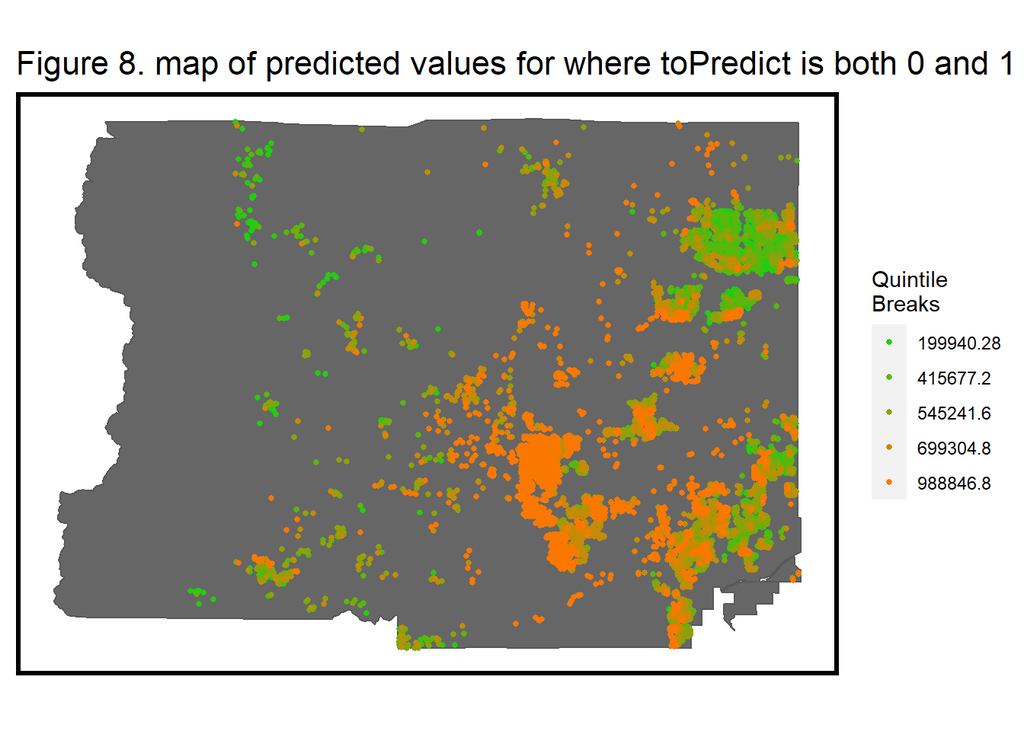

```r
housing.test.all <- housing
housing.test.all <- housing.test.all%>%
  mutate(Regression = "Neighbourhood effects",
         price.Predict = predict(reg.nhood.training, housing.test.all),
         price.Error = price.Predict - price,
         price.AbsError = abs(price.Predict - price),
         price.APE = (abs(price.Predict - price)) /
           price.Predict)%>%
  filter(price < 8000000)
ggplot() +
  geom_sf(data = Boulder.county.reproject, fill = "grey40") +
  geom_sf(data = housing.test.all, aes(colour = q5(price.Predict)),
          show.legend = "point", size = 1) +
  scale_colour_manual(values = palette5,
                      labels=qBr(housing.test.all,"price.Predict"),
                      name="Quintile\nBreaks") +
  labs(title="Figure 8. map of predicted values for where toPredict is both 0 and 1") +
  mapTheme()
```

### 4.7 MAPE by neighborhood

Using the test set prediction, mean absolute percentage error (MAPE) by neighborhood is mapped as Figure 9. Most neighhourhoods have low value of MAPE, which is below 0.4. Notably, in the central Boulder county, one neighbourhood was significantly high, which exceeds 100%. Probably because this area has limited houses and more easily caused distortion.

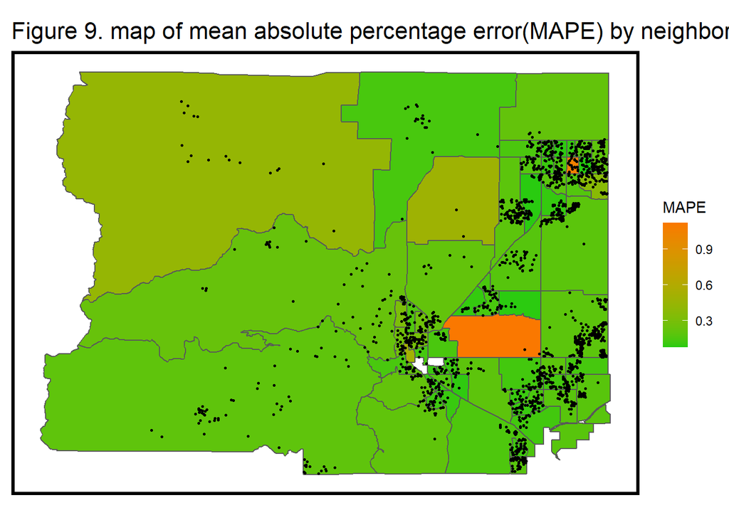

```r
st_drop_geometry(housing.test.nhood)%>%
  group_by(GEOID) %>%
  summarise(MAPE = mean(price.APE, na.rm = T))%>%
  ungroup()%>%
  left_join(neighborhood)%>%
  st_sf()%>%
  ggplot() +
  geom_sf(aes(fill = MAPE)) +
  geom_sf(data = housing.test.nhood, colour ="black", size =.5) +
  scale_fill_gradient(low = palette5[1], high = palette5[5],
                      name = "MAPE") +
  labs(title = "Figure 9. map of mean absolute percentage error(MAPE) by neighborhood") +
  mapTheme()
```

Figure 10 plots the mean MAPE by neighborhood as a function of mean price by neighborhood. Except for few outliers, the MAPE is relatively stable and is below 0.4, which suggests good generalizability of our model.

```r
nhood.summary <- housing.test.nhood %>%
  group_by(GEOID) %>%
  summarize(meanPrice = mean(price, na.rm = T),
            meanPrediction = mean(price.Predict, na.rm = T),
            meanMAE = mean(price.AbsError, na.rm = T),
            MAPE=mean(price.APE, na.rm = T))

nhood.summary %>%
  st_drop_geometry %>%
  arrange(desc(meanMAE)) %>%
  knitr::kable() %>% kable_styling()
```

| GEOID | meanPrice | meanPrediction | meanMAE | MAPE |
| --- | --- | --- | --- | --- |
| 08013012707 | 2120500.0 | 1166850.7 | 1273518.75 | 1.1238463 |
| 08013013202 | 2226250.0 | 1776044.6 | 918029.34 | 0.4859673 |
| 08013012204 | 798350.0 | 1621731.4 | 823381.40 | 0.5106646 |
| 08013012101 | 2290516.7 | 2067379.8 | 569175.45 | 0.2693979 |
| 08013012103 | 1404588.2 | 1337481.9 | 440614.70 | 0.2642201 |
| 08013012102 | 1406130.0 | 1278106.9 | 398836.43 | 0.2870487 |
| 08013012104 | 1014168.7 | 1301185.4 | 394024.46 | 0.3140760 |
| 08013012505 | 1398710.5 | 1359648.7 | 304612.49 | 0.2173348 |
| 08013012701 | 1224512.9 | 1116642.0 | 295421.07 | 0.2183454 |
| 08013012201 | 2014471.4 | 1876777.7 | 283350.50 | 0.1423570 |
| 08013012510 | 1260266.7 | 1180778.0 | 276279.93 | 0.2093141 |
| 08013012401 | 1132791.7 | 1280710.3 | 274719.39 | 0.2138087 |
| 08013012710 | 1079828.6 | 1228024.5 | 251959.46 | 0.1995180 |
| 08013013205 | 1162228.5 | 1255044.4 | 235572.86 | 0.1791924 |
| 08013012105 | 1382153.8 | 1330401.1 | 222853.53 | 0.1573124 |
| 08013012903 | 770633.3 | 853343.6 | 201922.28 | 0.1961022 |
| 08013013701 | 911678.8 | 873731.8 | 201628.80 | 0.2328420 |
| 08013013201 | 739500.0 | 872439.4 | 175776.96 | 0.2174667 |
| 08013013503 | 467741.7 | 338356.2 | 173040.03 | 1.0628816 |
| 08013012511 | 1139250.0 | 970878.5 | 168994.98 | 0.1695412 |
| 08013013602 | 350129.4 | 373474.0 | 151727.96 | 0.4345501 |
| 08013012202 | 1070925.0 | 1003688.6 | 134416.38 | 0.1345300 |
| 08013013402 | 506371.4 | 467595.4 | 130221.07 | 0.3728257 |
| 08013061400 | 721897.9 | 741355.8 | 129741.97 | 0.1825475 |
| 08013012800 | 663073.8 | 683950.5 | 127966.92 | 0.1950462 |
| 08013013213 | 704024.5 | 695430.2 | 121345.35 | 0.1947325 |
| 08013013003 | 748582.1 | 820966.9 | 121063.08 | 0.1287529 |
| 08013012708 | 728356.9 | 784143.6 | 119787.89 | 0.1424354 |
| 08013060700 | 805805.6 | 826428.3 | 116788.44 | 0.1280086 |
| 08013012603 | 996720.0 | 963564.5 | 115047.43 | 0.1122261 |
| 08013060600 | 623158.3 | 685646.4 | 110131.48 | 0.1553547 |
| 08013012509 | 884500.0 | 914385.7 | 110110.16 | 0.1193184 |
| 08013013702 | 578085.9 | 588847.6 | 106741.35 | 0.2055834 |
| 08013013005 | 862844.4 | 830690.1 | 104235.80 | 0.1480960 |
| 08013060900 | 665766.7 | 659528.2 | 103482.74 | 0.1833571 |
| 08013060800 | 533064.3 | 519844.9 | 93364.76 | 0.1825616 |
| 08013013601 | 665925.0 | 696686.9 | 88760.92 | 0.1414480 |
| 08013013004 | 752631.2 | 756682.4 | 86471.70 | 0.1116169 |
| 08013013006 | 723474.4 | 742955.9 | 84629.70 | 0.1091599 |
| 08013013302 | 487274.4 | 464067.2 | 84497.17 | 0.1930581 |
| 08013013211 | 560723.9 | 532946.5 | 83426.29 | 0.1933349 |
| 08013012608 | 651090.9 | 619179.0 | 82783.69 | 0.1293464 |
| 08013013508 | 492277.0 | 508276.7 | 77933.09 | 0.2010885 |
| 08013012203 | 552178.9 | 552744.1 | 77187.08 | 0.1454108 |
| 08013061300 | 760837.0 | 716928.6 | 77107.80 | 0.1214151 |
| 08013013208 | 479793.5 | 471337.1 | 76043.49 | 0.1742847 |
| 08013013401 | 361942.9 | 425785.0 | 74706.87 | 0.1682240 |
| 08013012905 | 483333.3 | 484521.0 | 73558.65 | 0.1673199 |
| 08013012907 | 483635.6 | 530540.3 | 73424.42 | 0.1354508 |
| 08013012705 | 757411.1 | 745427.4 | 73238.90 | 0.1011871 |
| 08013012507 | 671218.2 | 685611.4 | 72625.75 | 0.1048037 |
| 08013012501 | 804266.7 | 794134.6 | 72184.49 | 0.0923170 |
| 08013012508 | 735550.0 | 694082.5 | 72159.15 | 0.1068274 |
| 08013013308 | 389150.0 | 425392.5 | 72043.64 | 0.1527908 |
| 08013012904 | 596509.5 | 585442.7 | 71110.95 | 0.1317329 |
| 08013013207 | 534327.3 | 539925.1 | 70813.58 | 0.1479728 |
| 08013012607 | 617433.3 | 640693.1 | 70589.73 | 0.1103053 |
| 08013013506 | 476996.4 | 454730.9 | 61513.88 | 0.1681004 |
| 08013012709 | 663875.0 | 640852.1 | 59984.50 | 0.0863425 |
| 08013013305 | 368845.6 | 380597.2 | 44313.41 | 0.1177579 |
| 08013013307 | 389977.8 | 384569.1 | 42429.32 | 0.1101306 |
| 08013013210 | 385119.0 | 389124.1 | 41046.18 | 0.1020875 |
| 08013013212 | 460527.8 | 474533.4 | 39894.48 | 0.0844196 |
| 08013013505 | 354450.0 | 345362.8 | 34131.12 | 0.1010426 |
| 08013013507 | 390552.0 | 394478.7 | 32998.27 | 0.0790556 |
| 08013013306 | 375133.3 | 367951.7 | 32391.78 | 0.0904617 |

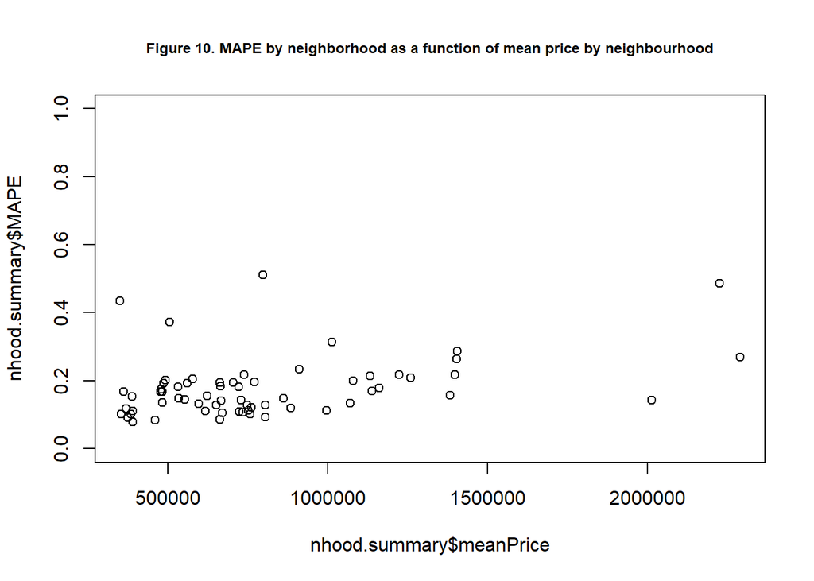

```r
map_MAPE <- housing.test.nhood %>%
  group_by(GEOID) %>%
  summarise(MAPE = mean(price.APE, na.rm = T))

plot(nhood.summary$meanPrice,
     nhood.summary$MAPE,
     main="Figure 10. MAPE by neighborhood as a function of mean price by neighbourhood",
     cex.main=0.75, ylim=range(0:1))
```